# Assignment I - CompStat2023

Aldo Giovanni e Giacomo

Anuja Saira Abraham 5204982, Alessia Marzotti 5108443, Miriam Mercuri 5207057

# Simulation problem:

# Exeercise 1

## Point a

Compute $P [\max(X_1, X_2) > Y_1]$.

We know that $Z=max(X_1,X_2) \in (1,2,3,4,5,6)$ and that $P(Z=z)=(2(z-1)+1)/36$. In other word we want to find $P(Z>y)=1-P(Z \leq y)$. $P(Z \leq y)=\\P(Z=1 \cap y=1)+\\P(Z=1 \cap y=2)+P(Z=2 \cap y=2)+\\P(Z=1 \cap y=3)+P(Z=2 \cap y=3)+P(Z=3 \cap y=3)+\\P(Z=1 \cap y=4)+P(Z=2 \cap y=4)+P(Z=3 \cap y=4)+P(Z=4 \cap y=4)+\\P(Z=1 \cap y=5)+P(Z=2 \cap y=5)+P(Z=3 \cap y=5)+P(Z=4 \cap y=5)+P(Z=5 \cap y=5)+\\P(Z=1 \cap y=6)+P(Z=2 \cap y=6)+P(Z=3 \cap y=6)+P(Z=4 \cap y=6)+P(Z=5 \cap y=6)+P(Z=6 \cap y=6)$

So we have $P(Z \leq y)= 6\frac{1}{36}\frac{1}{6}+5\frac{3}{36}\frac{1}{6}+4\frac{5}{36}\frac{1}{6}+3\frac{7}{36}\frac{1}{6}+2\frac{9}{36}\frac{1}{6}+\frac{11}{36}\frac{1}{6}\approx0,421$ and
$$P(Z>y)=1 - 0,421=0,579$$

## Point b-c-d

Here there are some code to simulate a generic Risiko! game for different values of competing units.

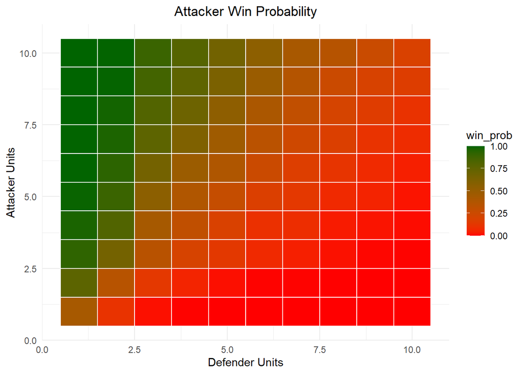

```r
library(ggplot2)
set.seed(123)
combat_round <- function(att_units,def_units,sim=10000) {
  Results = rep(NA,sim)
  AS<-att_units
  DS<-def_units
  for(i in 1:sim){
    while(def_units>0 & att_units>0){
      Dnum <- sort(sample(1:6, min(def_units,3),replace = TRUE),decreasing = T)
      Anum <- sort(sample(1:6, min(att_units,3),replace = TRUE),decreasing = T)
      for (j in 1:min(length(Dnum),length(Anum))){
        if(Anum[j]>Dnum[j]){
          def_units<-def_units-1
        }
        else{
          att_units<-att_units-1
        }
      }
    }
    Results[i]<- ifelse(att_units>0,1,0)
    att_units<-AS
    def_units<-DS
  }
  return(mean(Results))
}

prob_att_win <- function(){
  res<-sapply(1:10, function(x) {
  sapply(1:10, function(y) {
    combat_round(y,x,1000)
    })
  })
  return(res)
}
# Print the result
#print(result)


att_prob<- data.frame(
  attacker_unit<- rep(1:10,10),
  defender_unit<- rep(1:10,each= 10),
  win_prob<- as.vector(prob_att_win())
)


#go through outer
ggplot(att_prob,aes(x=defender_unit,y=attacker_unit,fill=win_prob))+
  geom_tile()+
  scale_fill_gradient(low="red",high="darkgreen")+
  labs(title = "Attacker Win Probability",x="Defender Units",y="Attacker Units")+
  geom_tile(color = "white",lwd = 0.5,linetype = 1)+
  theme_minimal()+
  theme(plot.title = element_text(hjust = 0.5))
```

```r
print(combat_round(def_units=1,att_units=2,sim=10000))
```

```
## [1] 0.7561
```

# Monte Carlo simulations I

## Point a

$E(X)=\int_a^b\frac{x}{b-a}dx=\frac{b^2-a^2}{2(b-a)}$

$E(Z)=E(\sum_{i=1}^{12}U_i)$ $=\sum_{i=1}^{12}E(U_i)$ independent $=12E(U_i)$ identically distributed $12\frac{\frac{1}{2}^2-(-\frac{1}{2})^2}{2(\frac{1}{2}-(-\frac{1}{2}))}=0$

$V(Z)=E[(X-E(X))^2]=\int_a^b(x-\frac{a+b}{2})^2\frac{dx}{b-a}=\frac{(b-a)^2}{12}$

$V(Z)=V(\sum_{i=1}^{12}U_i)$ $=\sum_{i=1}^{12}V(U_i)$ variable independent $=12V(U_i)$ $U_i$ identically distributed $=12\frac{(\frac{1}{2}-(-\frac{1}{2}))^2}{12}$ $=12\frac{(\frac{1}{2}+\frac{1}{2})^2}{12}=1$

```r
set.seed(13)



normal_functn_gen = function(sim){
  n<-12
  Uz<-runif(sim*n,min = -0.5,max = 0.5)
  Uz<-matrix(Uz,nrow=N,ncol=n)
  Z<-apply(Uz,1,sum)
  return(Z)
}

N <- 10000

gen_norm<-normal_functn_gen(sim=10000)
mean(gen_norm)
```

```
## [1] 0.01682814
```

```r
var(gen_norm)
```

```
## [1] 0.9994385
```

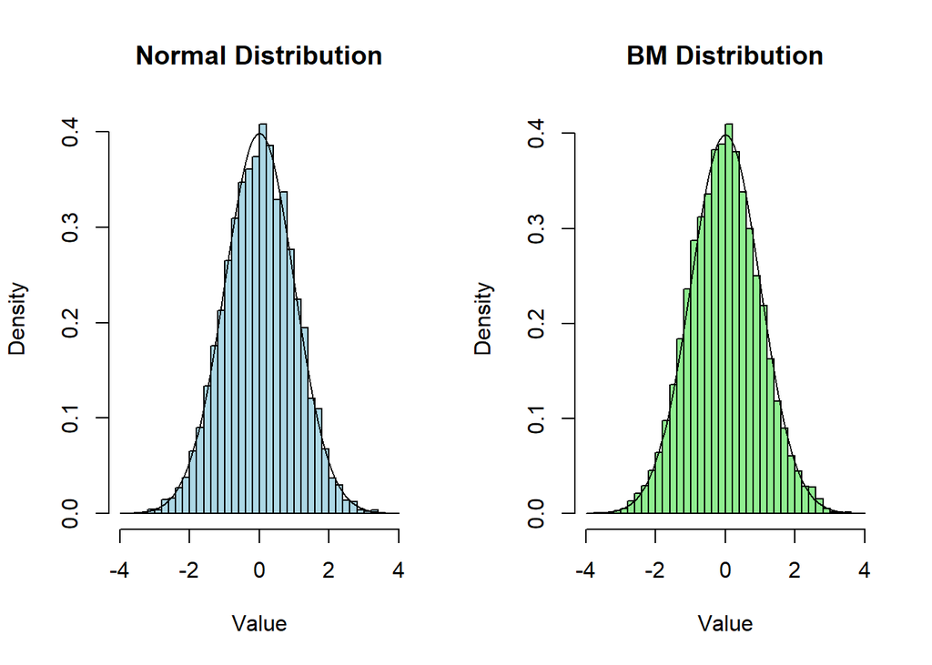

```r
U1 <- runif(N)
U2 <- runif(N)
X1 <- sqrt( -2*log(U1) )*cos(2*pi*U2)

par(mfrow=c(1,2))
hist(gen_norm, main="Normal Distribution", xlab="Value",col="lightblue" ,breaks=30,freq = F,xlim=c(-4,4))
curve(dnorm(x,0,1),add=T)
hist(X1, main="BM Distribution", xlab="Value",col="lightgreen" ,breaks=30,freq = F,xlim=c(-4,4))
curve(dnorm(x,0,1),add=T)
```

# Monte Carlo simulations II

## Point a

The Pareto distribution is defined by a density $f(x;\gamma)=\gamma x^{-(\gamma +1)}$ over $(1;+\infty)$, with $\gamma >0$.

It can be generated as the $-\frac{1}{\gamma}$ power of a uniform r.v.

Cumulative distribution function of Pareto distribution $\int_1^x \gamma z^{-(\gamma +1)} dz= \gamma \int_1^x z^{-1-\gamma}dz=-[x^{-\gamma}-1^{-\gamma}]=-x^{-\gamma}+1=1-(\frac{1}{x})^{\gamma}$

We will use the following theorem: if $X \sim F(x)$ then $U=F(x) \sim U(0,1)$ $F(X)=1-(\frac{1}{x})^{\gamma}=U$ $(1-U)^{-\frac{1}{\gamma}}=(x^{\gamma})^{-\frac{1}{\gamma}}$ $x=(1-U)^{-\frac{1}{\gamma}}=U^{-\frac{1}{\gamma}}$

## Pont b

Reference: Wikipedia The Pareto distribution is related to the exponential distribution as follows. If X is Pareto-distributed with minimum $x_m$ and index $\alpha$, then $Y=log(\frac{X}{x_m})$ is exponentially distributed with rate parameter $\alpha$.

$Y=log(\frac{X}{x_m}) \sim Exp(\gamma)$ $Y=log(X) \sim Exp(\gamma)$

##Point c

Implement two samplers, one for X and one for Y . Plot the histogram and the density and comment on the results exploring different values of Y.

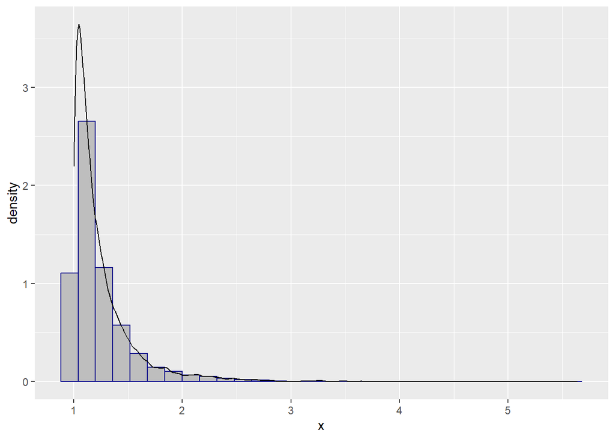

```r
#Implement two samplers, one for X and one for Y. Plot the histogram and the density
#and comment on the results exploring different values of γ.
library(patchwork)
#sampler for Pareto
xsampler<- function(n, gamma){
  u<- runif(n)
  x<-1/((1-u)^(1/gamma))
  return(x)
}

#sampler for Exponential
ysampler<- function(x){
  y<- log(x)
  return(y)
}
i=0
gamma = c(5,10,20)

x1=xsampler(10000,10)
y1=ysampler(x1)
x2<-xsampler(10000,10)
y2<- ysampler(x2)

library(ggplot2)

ggplot(data.frame(x=xsampler(10000,gamma[1])), aes(x)) +
  geom_histogram(aes(y=..density..), fill="gray",col="darkblue")+
  geom_density()
```

Implement two samplers, one for X and one for Y . Plot the histogram and the density and comment on the results exploring different values of γ.

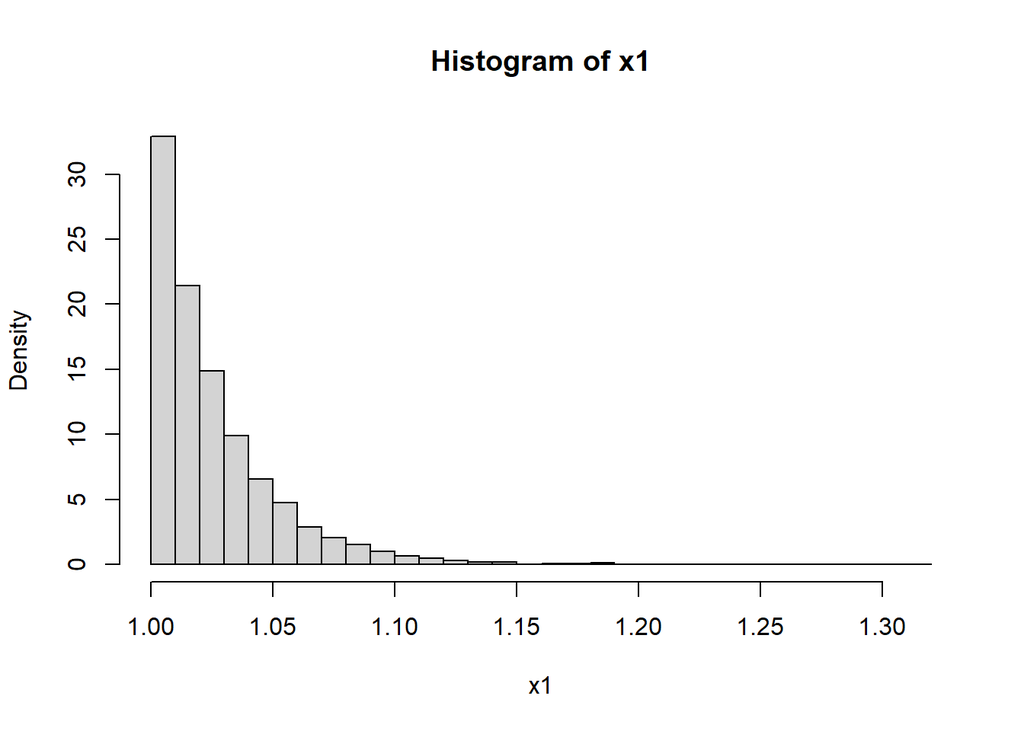

```r
#sampler for Pareto
xsampler<- function(n, gamma){
  u<- runif(n)
  1/((1-u)^(1/gamma))
}

#sampler for exponential
ysampler<- function(n,gamma){
  x<- xsampler(n,gamma)
  y<- log(x)
  return(y)
}

x1=xsampler(10000,40)
y1=ysampler(10000,40)
hist(x1,breaks = 30, freq=F)
```

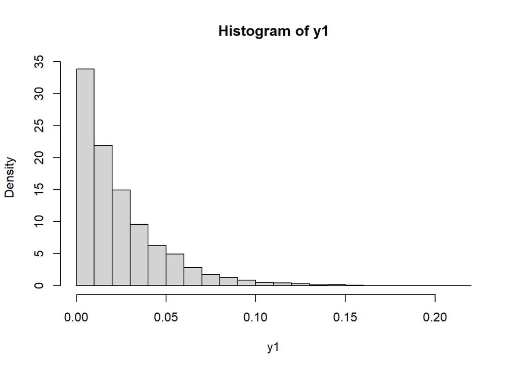

```r
hist(y1,breaks = 30, freq=F)
```

# MC integration

## Point a

We write the probability of a standard Normal r.v. X as an integral thanks to its probability density function.

$P(X>20)=\int_{20}^\infty \frac{1}{\sqrt{2\pi}} e^{-\frac{x^{2}}{2}} dx$

Reference: Wikipedia

The crude Monte Carlo estimation of this quantity is deemed to fail because the region of integration is so far out in the tails of the standard normal distribution.

## Point b

Rewrite the integral employing the change of variable $Y = \frac{1}{X}$.

$dy=-\frac{1}{x^{2}} dx\\dx=-x^{2}dy=-\frac{1}{y^{2}}dy\\y=Y_{20}=0,05\\y=Y_\infty=0$

So $\int_{20}^\infty \frac{1}{\sqrt{2\pi}} e^{-\frac{x^{2}}{2}} dx\\=\int_{0,05}^0 \frac{1}{\sqrt{2\pi}} e^{-\frac{1}{2y^{2}}} -\frac{1}{y^2} dy \\=\int_0^{0,05} \frac{1}{\sqrt{2\pi}} e^{-\frac{1}{2y^{2}}} \frac{1}{y^2} dy$